# Master en Big Data. Fundamentos Matemáticos del Análisis de Datos (FMAD).

Tarea 1

García Vázquez, Carlos

Curso 2021-22. Última actualización: 2021-09-16

# Preliminares

Cargamos en memoria los paquetes que van a ser necesarios durante la ejecución de la práctica.

```r
library(tidyverse) # Ya tiene incorporadas dplyr y ggplot
library(gridExtra)
#Este tercero, lo necesitaremos para acceder a los datos necesarios en el segundo apartado
#del último ejercicio
library(nycflights13)
```

# Instrucciones preliminares

- Empieza abriendo el proyecto de RStudio correspondiente a tu repositorio personal de la asignatura.
- En todas las tareas tendrás que repetir un proceso como el descrito en la sección *Repite los pasos Creando un fichero Rmarkdown para esta práctica* de la *Práctica00*. Puedes releer la sección *Practicando la entrega de las Tareas* de esa misma práctica para recordar el procedimiento de entrega.

# Ejercicio 1. Análisis exploratorio de un conjunto de datos y operaciones con dplyr.

- Vamos a utilizar el conjunto de datos contenido en el fichero (es un enlace):  
  cholesterol.csv  
  Los datos proceden de un estudio realizado en la *University of Virginia School of Medicine* que investiga la prevalencia de la obesidad, la diabetes y otros factores de riesgo cardiovascular. Se puede encontrar más información sobre el fichero en este enlace:  
  https://biostat.app.vumc.org/wiki/pub/Main/DataSets/diabetes.html
- Carga el conjunto de datos en un data.frame de R llamado `chlstrl`.

```r
#Cargamos los datos requeridos
chlstrl=read_csv("./data/cholesterol.csv")
```

- Empezaremos por información básica sobre el conjunto de datos. Cuántas observaciones contiene, cuáles son las variables y de qué tipos,…

```r
#Obtenemos una primera visualización de la estructura de datos que contiene la tabla
head(chlstrl)
```

```
## # A tibble: 6 x 7
##    chol   age gender height weight waist   hip
##   <dbl> <dbl> <chr>   <dbl>  <dbl> <dbl> <dbl>
## 1   203    46 female     62    121    29    38
## 2   165    29 female     64    218    46    48
## 3   228    58 female     61    256    49    57
## 4    78    67 male       67    119    33    38
## 5   249    64 male       68    183    44    41
## 6   248    34 male       71    190    36    42
```

Analizamos el número de variables totales a manejar, los tipos, número de registros…

```r
#Número de registros con el que trabajaremos
nrow(chlstrl)
```

```
## [1] 403
```

```r
#Número de variables con las que trabajaremos
ncol(chlstrl)
```

```
## [1] 7
```

```r
#Resumen con información básica adicional, como podría ser la tipología de datos que vamos a manejar
str(chlstrl)
```

```
## spec_tbl_df [403 x 7] (S3: spec_tbl_df/tbl_df/tbl/data.frame)
##  $ chol  : num [1:403] 203 165 228 78 249 248 195 227 177 263 ...
##  $ age   : num [1:403] 46 29 58 67 64 34 30 37 45 55 ...
##  $ gender: chr [1:403] "female" "female" "female" "male" ...
##  $ height: num [1:403] 62 64 61 67 68 71 69 59 69 63 ...
##  $ weight: num [1:403] 121 218 256 119 183 190 191 170 166 202 ...
##  $ waist : num [1:403] 29 46 49 33 44 36 46 34 34 45 ...
##  $ hip   : num [1:403] 38 48 57 38 41 42 49 39 40 50 ...
##  - attr(*, "spec")=
##   .. cols(
##   ..   chol = col_double(),
##   ..   age = col_double(),
##   ..   gender = col_character(),
##   ..   height = col_double(),
##   ..   weight = col_double(),
##   ..   waist = col_double(),
##   ..   hip = col_double()
##   .. )
##  - attr(*, "problems")=<externalptr>
```

- Asegúrate de comprobar si hay datos ausentes y localízalos en la tabla.

En este tipo de ejercicios, resulta fundamental tener en cuenta los datos ausentes con los que contamos.

```r
#Sacamos el número de datos ausentes en toda la tabla, detectando de esta forma su presencia
table(is.na(chlstrl)) #Tener en cuenta los TRUE
```

```
##
## FALSE  TRUE
##  2810    11
```

```r
#Los localizamos en el DataFrame, analizando las posiciones que ocupan
head(is.na(chlstrl)) #Imprimimos solo el head
```

```
##       chol   age gender height weight waist   hip
## [1,] FALSE FALSE  FALSE  FALSE  FALSE FALSE FALSE
## [2,] FALSE FALSE  FALSE  FALSE  FALSE FALSE FALSE
## [3,] FALSE FALSE  FALSE  FALSE  FALSE FALSE FALSE
## [4,] FALSE FALSE  FALSE  FALSE  FALSE FALSE FALSE
## [5,] FALSE FALSE  FALSE  FALSE  FALSE FALSE FALSE
## [6,] FALSE FALSE  FALSE  FALSE  FALSE FALSE FALSE
```

```r
#Hacemos la cuenta de entre los 403 registros, de cuales son los que contienen algún valor nulo
table(complete.cases(chlstrl)) #Tener en cuenta los FALSE
```

```
##
## FALSE  TRUE
##     9   394
```

```r
#Con la siguiente instrucción, localizamos las filas con algún dato ausente
head(complete.cases(chlstrl)) # Imprimimos solo el head
```

```
## [1] TRUE TRUE TRUE TRUE TRUE TRUE
```

```r
#Finalmente, con el summary, obtenemos el número de nulos en cada una de las variables contempladas
#en la tabla
summary(chlstrl)
```

```
##       chol            age           gender              height
##  Min.   : 78.0   Min.   :19.00   Length:403         Min.   :52.00
##  1st Qu.:179.0   1st Qu.:34.00   Class :character   1st Qu.:63.00
##  Median :204.0   Median :45.00   Mode  :character   Median :66.00
##  Mean   :207.8   Mean   :46.85                      Mean   :66.02
##  3rd Qu.:230.0   3rd Qu.:60.00                      3rd Qu.:69.00
##  Max.   :443.0   Max.   :92.00                      Max.   :76.00
##  NA's   :1                                          NA's   :5
##      weight          waist           hip
##  Min.   : 99.0   Min.   :26.0   Min.   :30.00
##  1st Qu.:151.0   1st Qu.:33.0   1st Qu.:39.00
##  Median :172.5   Median :37.0   Median :42.00
##  Mean   :177.6   Mean   :37.9   Mean   :43.04
##  3rd Qu.:200.0   3rd Qu.:41.0   3rd Qu.:46.00
##  Max.   :325.0   Max.   :56.0   Max.   :64.00
##  NA's   :1       NA's   :2      NA's   :2
```

Una vez disponemos de la información suficiente sobre la presencia de datos ausentes en la tabla, tenemos que decidir cómo gestionar su presencia.

En este caso, se ha decidido, que en las funciones en las que se considere necesario para su correcta utilización, se incorpore el parámetro opcional na.rm=TRUE para ignorar los nulos y que no pasen inadvertidos.

- El análisis exploratorio (numérico y gráfico) debe cubrir todos los tipos de variable de la tabla. Es decir, que al menos debes estudiar una variable por cada tipo de variable presente en la tabla. El análisis debe contener, al menos:
  - Para las variables cuantitativas (continuas o discretas).  
    Resumen numérico básico.  
    Gráficas (las adecuadas, a ser posible más de un tipo de gráfico).

De entre las variables cuantitativas y continuas, seleccionamos la variable ‘chol’ para trabajarla y estudiarla

RESUMEN NUMÉRICO DE LA VARIABLE

```r
#Sacamos el mínimo, máximo,media,mediana, cuartiles y datos ausentes de la variable seleccionada
summary(chlstrl$chol)
```

```
##    Min. 1st Qu.  Median    Mean 3rd Qu.    Max.    NA's
##    78.0   179.0   204.0   207.8   230.0   443.0       1
```

Como ya sabemos, la media se suele ver muy influenciada por la presencia de valores atípicos, al contrario que la mediana, que por su construcción, no se ve tan afectada por estos. De esta forma, la comparación entre ambas nos puede dar información determinante acerca de la presencia de este tipo de valores en la muestra, que si no se tratan correctamente, pueden llevar a interpretaciones erróneas de los datos.

```r
#Calculamos el recorrido intercuartílico
IQR(chlstrl$chol, na.rm = TRUE)
```

```
## [1] 51
```

```r
#Los valores atípicos
unname(quantile(chlstrl$chol, probs = c(1/4, 3/4),na.rm=TRUE)
       + c(-1, 1) * 1.5 * IQR(chlstrl$chol, na.rm = TRUE))
```

```
## [1] 102.5 306.5
```

Con estas 2 últimas funciones, tenemos un mayor conocimiento de la dispersión de la variable a estudiar. Y concretamente, con la función unname(), conocemos el rango (102.5-306.5) a partir del cual podremos distinguir los valores atípicos de la muestra.

```r
#Desviación típica
sd(chlstrl$chol, na.rm = TRUE)
```

```
## [1] 44.44556
```

```r
#Varianza
var(chlstrl$chol, na.rm = TRUE)
```

```
## [1] 1975.408
```

Por último, hemos calculado tanto la varianza como la desviación típica de la variable, para tener aún más información acerca de la dispersión y variabilidad que tienen lo datos respecto a su media.

De esta forma, podemos completar el estudio y tener un resumen global a nivel numérico del comportamiento de la variable ‘chol’

GRÁFICAS

1. Histograma

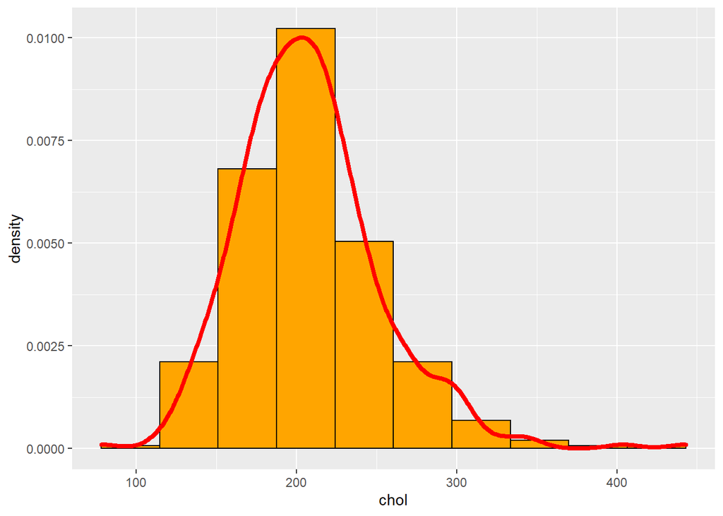

```r
#FORMA 1

#Hacemos los cortes para realizar 10 intervalos, omitiendo los valores nulos de la variable
cortes = seq(min(chlstrl$chol,na.rm=TRUE), max(chlstrl$chol,na.rm=TRUE), length.out = 11)
#Graficamos
ggplot(chlstrl, aes(x = chol)) +
  geom_histogram(aes(y=stat(density)),
                 breaks=cortes, fill = "orange", color="black")  +
  geom_density(color="red", size=1.5)
```

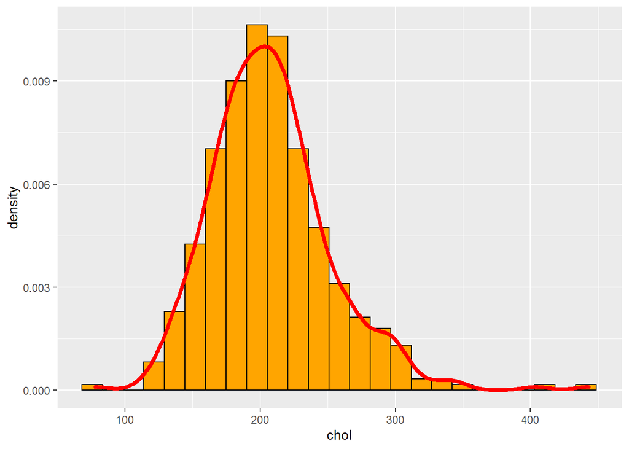

```r
#FORMA 2

#En este caso, especificamos el número de intervalos con bins
#Lo dividiremos en 25 intervalos, en este caso sin especificar de forma explicita los intervalos
ggplot(chlstrl, aes(x = chol)) +
  geom_histogram(aes(y=stat(density)),
                 bins=25, fill = "orange", color="black")  +
  geom_density(color="red", size=1.5)
```

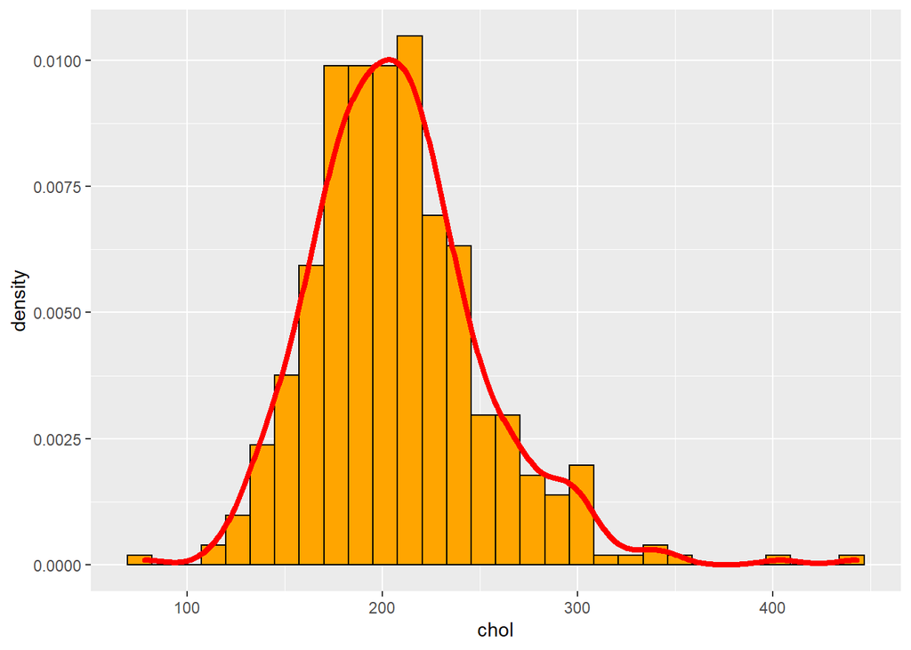

```r
#FORMA 3

#En este último caso, simplemente dejamos que R defina los intervalos
ggplot(chlstrl, aes(x = chol)) +
  geom_histogram(aes(y=stat(density))
                 , fill = "orange", color="black")  +
  geom_density(color="red", size=1.5)
```

Mediante el histograma se puede apreciar la distribución de la variable a estudiar, que es asimétrica a la derecha y se asemeja a la normal.

2. Boxplot

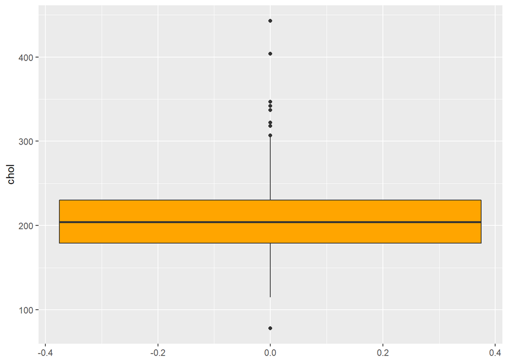

```r
#Boxplot normal
#Podemos ver como los valores atípicos se grafican individualmente
ggplot(chlstrl) +
  geom_boxplot(mapping = aes(y = chol), fill="orange")
```

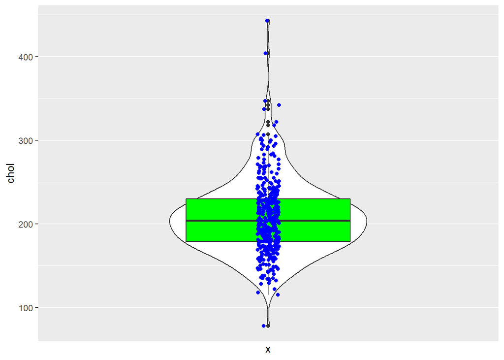

```r
#Violinplot
ggplot(chlstrl) +
  geom_violin(mapping = aes(x=0, y = chol)) +
  scale_x_discrete(breaks = c()) +
  geom_boxplot(mapping = aes(y = chol), fill="green") +
  geom_jitter(aes(x=0, y = chol),
              position = position_jitter(w=0.05, h= 0), col="blue")
```

El Boxplot y Violinplot representados, también nos permiten hacernos una idea de la distribución de la variable, además de identificar los valores atípicos.

- Variables categóricas (factores).  
  Tablas de frecuencia (absolutas y relativas).  
  Gráficas (diagrama de barras).

Como variable categórica haremos uso de ‘gender’, que es la única de este tipo que podemos encontrar en el DataFrame

INFORMACIÓN DE LA VARIABLE

```r
summary(chlstrl$gender)
```

```
##    Length     Class      Mode
##       403 character character
```

TABLAS DE FRECUENCIA

```r
#table(chlstrl$gender) con R básico
chlstrl %>%
  count(gender) #Con dplyr
```

```
## # A tibble: 2 x 2
##   gender     n
##   <chr>  <int>
## 1 female   234
## 2 male     169
```

```r
#prop.table(table(chlstrl$gender)) con R básico
chlstrl %>%
  count(gender) %>%
    mutate(gender, relFreq = prop.table(n), n=NULL) #Con dplyr
```

```
## # A tibble: 2 x 2
##   gender relFreq
##   <chr>    <dbl>
## 1 female   0.581
## 2 male     0.419
```

GRÁFICO DE BARRAS

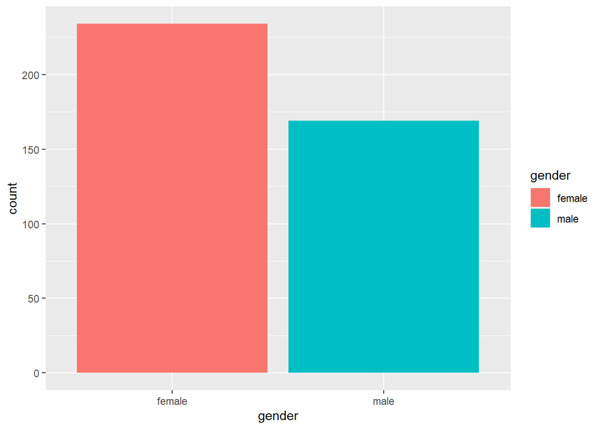

```r
ggplot(chlstrl) +
  geom_bar(aes(x=gender,fill=gender))
```

- Los valores de `height` y `weight` están en pulgadas (inches) y libras (pounds) respectivamente. Una libra son $\approx$ 0.454kg y una pulgada son $\approx$ 0.0254m. Usa dplyr para convertir esas columnas a metros y kilogramos respectivamente. Las nuevas columnas deben llamarse igual que las originales.

```r
#Cambiamos las unidades de los valores asociados a las variables 'height' y 'weight'
#sobreescribiendo chlstrl
(chlstrl=chlstrl %>%
    mutate(height=height*0.0254,weight=weight*0.454))
```

```
## # A tibble: 403 x 7
##     chol   age gender height weight waist   hip
##    <dbl> <dbl> <chr>   <dbl>  <dbl> <dbl> <dbl>
##  1   203    46 female   1.57   54.9    29    38
##  2   165    29 female   1.63   99.0    46    48
##  3   228    58 female   1.55  116.     49    57
##  4    78    67 male     1.70   54.0    33    38
##  5   249    64 male     1.73   83.1    44    41
##  6   248    34 male     1.80   86.3    36    42
##  7   195    30 male     1.75   86.7    46    49
##  8   227    37 male     1.50   77.2    34    39
##  9   177    45 male     1.75   75.4    34    40
## 10   263    55 female   1.60   91.7    45    50
## # ... with 393 more rows
```

- Ahora usa esos valores de `height` y `weight` para añadir una nueva columna llamada BMI, definida mediante:
  $$BMI = \dfrac{weight}{height^2}$$
  (se divide por el cuadrado de la altura).

```r
#Añadimos la nueva columna especificada
(chlstrl=chlstrl %>%
    mutate(BMI=weight/(height)^2))
```

```
## # A tibble: 403 x 8
##     chol   age gender height weight waist   hip   BMI
##    <dbl> <dbl> <chr>   <dbl>  <dbl> <dbl> <dbl> <dbl>
##  1   203    46 female   1.57   54.9    29    38  22.2
##  2   165    29 female   1.63   99.0    46    48  37.5
##  3   228    58 female   1.55  116.     49    57  48.4
##  4    78    67 male     1.70   54.0    33    38  18.7
##  5   249    64 male     1.73   83.1    44    41  27.8
##  6   248    34 male     1.80   86.3    36    42  26.5
##  7   195    30 male     1.75   86.7    46    49  28.2
##  8   227    37 male     1.50   77.2    34    39  34.4
##  9   177    45 male     1.75   75.4    34    40  24.5
## 10   263    55 female   1.60   91.7    45    50  35.8
## # ... with 393 more rows
```

- Crea una nueva columna llamada `ageGroup` dividiendo la edad en los siguientes tres niveles:

```r
#Añadimos la nueva columna especificada
(chlstrl=chlstrl %>%
    mutate(ageGroup=cut(age,breaks=c(10,40,70,100))))
```

```
## # A tibble: 403 x 9
##     chol   age gender height weight waist   hip   BMI ageGroup
##    <dbl> <dbl> <chr>   <dbl>  <dbl> <dbl> <dbl> <dbl> <fct>
##  1   203    46 female   1.57   54.9    29    38  22.2 (40,70]
##  2   165    29 female   1.63   99.0    46    48  37.5 (10,40]
##  3   228    58 female   1.55  116.     49    57  48.4 (40,70]
##  4    78    67 male     1.70   54.0    33    38  18.7 (40,70]
##  5   249    64 male     1.73   83.1    44    41  27.8 (40,70]
##  6   248    34 male     1.80   86.3    36    42  26.5 (10,40]
##  7   195    30 male     1.75   86.7    46    49  28.2 (10,40]
##  8   227    37 male     1.50   77.2    34    39  34.4 (10,40]
##  9   177    45 male     1.75   75.4    34    40  24.5 (40,70]
## 10   263    55 female   1.60   91.7    45    50  35.8 (40,70]
## # ... with 393 more rows
```

- Usando `dplyr` calcula cuántas observaciones hay en cada nivel de `ageGroup` (indicación: usa `group_by`). Ahora, usando aquellas observaciones que corresponden a mujeres, ¿cuál es la media del nivel de colesterol y de BMI en cada uno de esos grupos de edad?

```r
#Numero de observaciones para cada nivel de ageGroup
chlstrl %>%
  count(ageGroup)
```

```
## # A tibble: 3 x 2
##   ageGroup     n
##   <fct>    <int>
## 1 (10,40]    160
## 2 (40,70]    207
## 3 (70,100]    36
```

```r
#De entre las mujeres, media del nivel de colesterol y de BMI en cada uno de esos grupos de edad
chlstrl %>%
  filter(gender=='female') %>%
  group_by(ageGroup) %>%
  summarise(mediaCol=mean(chol,na.rm=TRUE),mediaBMI=mean(BMI,na.rm=TRUE))
```

```
## # A tibble: 3 x 3
##   ageGroup mediaCol mediaBMI
##   <fct>       <dbl>    <dbl>
## 1 (10,40]      189.     30.5
## 2 (40,70]      221.     30.3
## 3 (70,100]     230.     29.4
```

# Ejercicio 2: Funciones de R.

- Crea una función de R llamada `cambiosSigno` que dado un vector `x` de números enteros no nulos, como

  ```
  -12,  -19,  9,  -13,  -14,  -17,  8,  -19,  -14,
  ```

  calcule cuántos cambios de signo ha habido. Es decir, cuántas veces el signo de un elemento es distinto del signo del elemento previo. Por ejemplo, en el vector anterior hay 4 cambios de signo (en las posiciones 3, 4, 7 y 8).

```r
cambioSigno=function(x=sample(c(-1, 1), 9, replace = TRUE) * sample(1:20, 9, replace = TRUE)) {

  sol=list()
  cont=0
  for (i in 1:(length(x)-1)) {
    if ((x[i]>0 && x[i+1]<0) | (x[i]<0 && x[i+1]>0)){
      cont=cont+1
    }
  }
  sol$vector=x
  sol$cambSigno=cont
  returnValue(sol)
}
cambioSigno(x)
```

```
## $vector
## [1] -12 -19   9 -13 -14 -17   8 -19 -14
##
## $cambSigno
## [1] 4
```

```r
#Si no introduces nada
cambioSigno()
```

```
## $vector
## [1]   5  -1  14  -7   6  -6 -17 -16   6
##
## $cambSigno
## [1] 6
```

- Modifica la función para que devuelva como resultado las posiciones donde hay cambios de signo. Llama `cambiosSignoPos(x)` a esa otra función. Por ejemplo, para el vector anterior el resultado de esta función sería

```r
cambiosSignoPos=function(x=sample(c(-1, 1), 9, replace = TRUE) * sample(1:20, 9, replace = TRUE)) {
  sol=list()
  vectorPos=c()
  for (i in 1:(length(x)-1)) {
    if ((x[i]>0 && x[i+1]<0) | (x[i]<0 && x[i+1]>0)){
      vectorPos=c(vectorPos,i+1)
    }
  }
  sol$vector=x
  sol$posiciones=vectorPos
  returnValue(sol)
}
cambiosSignoPos(x)
```

```
## $vector
## [1] -12 -19   9 -13 -14 -17   8 -19 -14
##
## $posiciones
## [1] 3 4 7 8
```

```r
#Si no introduces nada
cambioSigno()
```

```
## $vector
## [1] -14  17 -16  -2  17 -13   1   9 -12
##
## $cambSigno
## [1] 6
```

Podemos ver como ambas funcionan , independientemente de si se les introduce un vector como argumento o no. Concretamente, en el caso de no introducir ningun vector, se crea uno por defecto.

# Ejercicio 3. R4DS.

Es recomendable que esta semana del curso hagas al menos una lectura somera de los Capítulos 1 a 5 de [R for Data Science (R4DS), de H. Wickham](https://r4ds.had.co.nz/index.html), con énfasis especial en los Capítulos 3 y 5 (los capítulos 1, 2 y 4 son muy breves). Los siguientes apartados pretenden motivar esa lectura y por eso mismo pueden resultar un poco más laboriosos.

- Haz el [ejercicio 6 de la Sección 3.6.1 de R4DS](https://r4ds.had.co.nz/data-visualisation.html#exercises-3).

```r
#Vemos la estructura de la tabla con los datos que se van a trabajar
head(mpg)
```

```
## # A tibble: 6 x 11
##   manufacturer model displ  year   cyl trans      drv     cty   hwy fl    class
##   <chr>        <chr> <dbl> <int> <int> <chr>      <chr> <int> <int> <chr> <chr>
## 1 audi         a4      1.8  1999     4 auto(l5)   f        18    29 p     compa~
## 2 audi         a4      1.8  1999     4 manual(m5) f        21    29 p     compa~
## 3 audi         a4      2    2008     4 manual(m6) f        20    31 p     compa~
## 4 audi         a4      2    2008     4 auto(av)   f        21    30 p     compa~
## 5 audi         a4      2.8  1999     6 auto(l5)   f        16    26 p     compa~
## 6 audi         a4      2.8  1999     6 manual(m5) f        18    26 p     compa~
```

Gráfico 1

```r
g1=ggplot(data = mpg, mapping = aes(x = displ, y = hwy)) +
  geom_point() +
  geom_smooth(se=FALSE)
```

Gráfico 2

```r
g2=ggplot(data = mpg,aes(x = displ, y = hwy)) +
  geom_point() +
  geom_smooth(aes(group = drv),se=FALSE)
```

Gráfico 3

```r
g3=ggplot(data = mpg,aes(x = displ, y = hwy,color=drv)) +
  geom_point() +
  geom_smooth(se=FALSE)
```

Gráfico 4

```r
g4=ggplot(data = mpg,aes(x = displ, y = hwy)) +
  geom_point(aes(color=drv)) +
  geom_smooth(se=FALSE)
```

Gráfico 5

```r
g5=ggplot(data = mpg,aes(x = displ, y = hwy)) +
  geom_point(aes(color=drv)) +
  geom_smooth(aes(linetype=drv),se=FALSE)
```

Gráfico 6

```r
g6=ggplot(data = mpg) +
  geom_point(aes(x = displ, y = hwy, fill=drv), shape = 21,color="white",size= 2.5, stroke = 1.5)
```

Mezclamos los 6 gráficos en una única representación

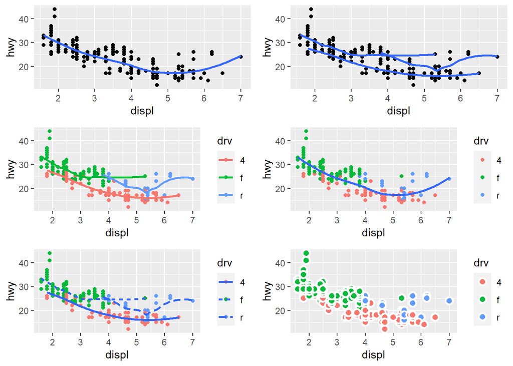

```r
grid.arrange(g1, g2, g3, g4, g5, g6, nrow = 3)
```

- Haz el [ejercicio 1 de la Sección 5.2.4 de R4DS](https://r4ds.had.co.nz/transform.html#exercises-8).

```r
#Vemos la estructura de la tabla con los datos que se van a trabajar
head(flights)
```

```
## # A tibble: 6 x 19
##    year month   day dep_time sched_dep_time dep_delay arr_time sched_arr_time
##   <int> <int> <int>    <int>          <int>     <dbl>    <int>          <int>
## 1  2013     1     1      517            515         2      830            819
## 2  2013     1     1      533            529         4      850            830
## 3  2013     1     1      542            540         2      923            850
## 4  2013     1     1      544            545        -1     1004           1022
## 5  2013     1     1      554            600        -6      812            837
## 6  2013     1     1      554            558        -4      740            728
## # ... with 11 more variables: arr_delay <dbl>, carrier <chr>, flight <int>,
## #   tailnum <chr>, origin <chr>, dest <chr>, air_time <dbl>, distance <dbl>,
## #   hour <dbl>, minute <dbl>, time_hour <dttm>
```

Find all flights that:

Had an arrival delay of two or more hours

```r
flights %>%
  filter(arr_delay>=2*60)
```

```
## # A tibble: 10,200 x 19
##     year month   day dep_time sched_dep_time dep_delay arr_time sched_arr_time
##    <int> <int> <int>    <int>          <int>     <dbl>    <int>          <int>
##  1  2013     1     1      811            630       101     1047            830
##  2  2013     1     1      848           1835       853     1001           1950
##  3  2013     1     1      957            733       144     1056            853
##  4  2013     1     1     1114            900       134     1447           1222
##  5  2013     1     1     1505           1310       115     1638           1431
##  6  2013     1     1     1525           1340       105     1831           1626
##  7  2013     1     1     1549           1445        64     1912           1656
##  8  2013     1     1     1558           1359       119     1718           1515
##  9  2013     1     1     1732           1630        62     2028           1825
## 10  2013     1     1     1803           1620       103     2008           1750
## # ... with 10,190 more rows, and 11 more variables: arr_delay <dbl>,
## #   carrier <chr>, flight <int>, tailnum <chr>, origin <chr>, dest <chr>,
## #   air_time <dbl>, distance <dbl>, hour <dbl>, minute <dbl>, time_hour <dttm>
```

Flew to Houston (IAH or HOU)

```r
flights %>%
  filter(dest %in% c('HOU','IAH'))
```

```
## # A tibble: 9,313 x 19
##     year month   day dep_time sched_dep_time dep_delay arr_time sched_arr_time
##    <int> <int> <int>    <int>          <int>     <dbl>    <int>          <int>
##  1  2013     1     1      517            515         2      830            819
##  2  2013     1     1      533            529         4      850            830
##  3  2013     1     1      623            627        -4      933            932
##  4  2013     1     1      728            732        -4     1041           1038
##  5  2013     1     1      739            739         0     1104           1038
##  6  2013     1     1      908            908         0     1228           1219
##  7  2013     1     1     1028           1026         2     1350           1339
##  8  2013     1     1     1044           1045        -1     1352           1351
##  9  2013     1     1     1114            900       134     1447           1222
## 10  2013     1     1     1205           1200         5     1503           1505
## # ... with 9,303 more rows, and 11 more variables: arr_delay <dbl>,
## #   carrier <chr>, flight <int>, tailnum <chr>, origin <chr>, dest <chr>,
## #   air_time <dbl>, distance <dbl>, hour <dbl>, minute <dbl>, time_hour <dttm>
```

Were operated by United, American, or Delta

```r
flights %>%
  filter(carrier %in% c('UA','AA','DL'))
```

```
## # A tibble: 139,504 x 19
##     year month   day dep_time sched_dep_time dep_delay arr_time sched_arr_time
##    <int> <int> <int>    <int>          <int>     <dbl>    <int>          <int>
##  1  2013     1     1      517            515         2      830            819
##  2  2013     1     1      533            529         4      850            830
##  3  2013     1     1      542            540         2      923            850
##  4  2013     1     1      554            600        -6      812            837
##  5  2013     1     1      554            558        -4      740            728
##  6  2013     1     1      558            600        -2      753            745
##  7  2013     1     1      558            600        -2      924            917
##  8  2013     1     1      558            600        -2      923            937
##  9  2013     1     1      559            600        -1      941            910
## 10  2013     1     1      559            600        -1      854            902
## # ... with 139,494 more rows, and 11 more variables: arr_delay <dbl>,
## #   carrier <chr>, flight <int>, tailnum <chr>, origin <chr>, dest <chr>,
## #   air_time <dbl>, distance <dbl>, hour <dbl>, minute <dbl>, time_hour <dttm>
```

Departed in summer (July, August, and September)

```r
flights %>%
  filter(month %in% c(7:9))
```

```
## # A tibble: 86,326 x 19
##     year month   day dep_time sched_dep_time dep_delay arr_time sched_arr_time
##    <int> <int> <int>    <int>          <int>     <dbl>    <int>          <int>
##  1  2013     7     1        1           2029       212      236           2359
##  2  2013     7     1        2           2359         3      344            344
##  3  2013     7     1       29           2245       104      151              1
##  4  2013     7     1       43           2130       193      322             14
##  5  2013     7     1       44           2150       174      300            100
##  6  2013     7     1       46           2051       235      304           2358
##  7  2013     7     1       48           2001       287      308           2305
##  8  2013     7     1       58           2155       183      335             43
##  9  2013     7     1      100           2146       194      327             30
## 10  2013     7     1      100           2245       135      337            135
## # ... with 86,316 more rows, and 11 more variables: arr_delay <dbl>,
## #   carrier <chr>, flight <int>, tailnum <chr>, origin <chr>, dest <chr>,
## #   air_time <dbl>, distance <dbl>, hour <dbl>, minute <dbl>, time_hour <dttm>
```

Arrived more than two hours late, but didn’t leave late

```r
flights %>%
  filter(dep_delay<=0,arr_delay>2*60)
```

```
## # A tibble: 29 x 19
##     year month   day dep_time sched_dep_time dep_delay arr_time sched_arr_time
##    <int> <int> <int>    <int>          <int>     <dbl>    <int>          <int>
##  1  2013     1    27     1419           1420        -1     1754           1550
##  2  2013    10     7     1350           1350         0     1736           1526
##  3  2013    10     7     1357           1359        -2     1858           1654
##  4  2013    10    16      657            700        -3     1258           1056
##  5  2013    11     1      658            700        -2     1329           1015
##  6  2013     3    18     1844           1847        -3       39           2219
##  7  2013     4    17     1635           1640        -5     2049           1845
##  8  2013     4    18      558            600        -2     1149            850
##  9  2013     4    18      655            700        -5     1213            950
## 10  2013     5    22     1827           1830        -3     2217           2010
## # ... with 19 more rows, and 11 more variables: arr_delay <dbl>, carrier <chr>,
## #   flight <int>, tailnum <chr>, origin <chr>, dest <chr>, air_time <dbl>,
## #   distance <dbl>, hour <dbl>, minute <dbl>, time_hour <dttm>
```

Were delayed by at least an hour, but made up over 30 minutes in flight

```r
flights %>%
  filter(dep_delay>=60,(arr_delay-dep_delay)<(-30))
```

```
## # A tibble: 1,844 x 19
##     year month   day dep_time sched_dep_time dep_delay arr_time sched_arr_time
##    <int> <int> <int>    <int>          <int>     <dbl>    <int>          <int>
##  1  2013     1     1     2205           1720       285       46           2040
##  2  2013     1     1     2326           2130       116      131             18
##  3  2013     1     3     1503           1221       162     1803           1555
##  4  2013     1     3     1839           1700        99     2056           1950
##  5  2013     1     3     1850           1745        65     2148           2120
##  6  2013     1     3     1941           1759       102     2246           2139
##  7  2013     1     3     1950           1845        65     2228           2227
##  8  2013     1     3     2015           1915        60     2135           2111
##  9  2013     1     3     2257           2000       177       45           2224
## 10  2013     1     4     1917           1700       137     2135           1950
## # ... with 1,834 more rows, and 11 more variables: arr_delay <dbl>,
## #   carrier <chr>, flight <int>, tailnum <chr>, origin <chr>, dest <chr>,
## #   air_time <dbl>, distance <dbl>, hour <dbl>, minute <dbl>, time_hour <dttm>
```

Departed between midnight and 6am (inclusive)

```r
flights %>%
  filter(dep_time ==2400 | dep_time<=600)
```

```
## # A tibble: 9,373 x 19
##     year month   day dep_time sched_dep_time dep_delay arr_time sched_arr_time
##    <int> <int> <int>    <int>          <int>     <dbl>    <int>          <int>
##  1  2013     1     1      517            515         2      830            819
##  2  2013     1     1      533            529         4      850            830
##  3  2013     1     1      542            540         2      923            850
##  4  2013     1     1      544            545        -1     1004           1022
##  5  2013     1     1      554            600        -6      812            837
##  6  2013     1     1      554            558        -4      740            728
##  7  2013     1     1      555            600        -5      913            854
##  8  2013     1     1      557            600        -3      709            723
##  9  2013     1     1      557            600        -3      838            846
## 10  2013     1     1      558            600        -2      753            745
## # ... with 9,363 more rows, and 11 more variables: arr_delay <dbl>,
## #   carrier <chr>, flight <int>, tailnum <chr>, origin <chr>, dest <chr>,
## #   air_time <dbl>, distance <dbl>, hour <dbl>, minute <dbl>, time_hour <dttm>
```